# ENV 790.30 - Time Series Analysis for Energy Data | Spring 2025

Assignment 3 - Due date 02/04/25

Ananya Aggarwal

## Directions

You should open the .rmd file corresponding to this assignment on RStudio. The file is available on our class repository on Github.

Once you have the file open on your local machine the first thing you will do is rename the file such that it includes your first and last name (e.g., “LuanaLima_TSA_A03_Sp25.Rmd”). Then change “Student Name” on line 4 with your name.

Then you will start working through the assignment by **creating code and output** that answer each question. Be sure to use this assignment document. Your report should contain the answer to each question and any plots/tables you obtained (when applicable).

Please keep this R code chunk options for the report. It is easier for us to grade when we can see code and output together. And the tidy.opts will make sure that line breaks on your code chunks are automatically added for better visualization.

When you have completed the assignment, **Knit** the text and code into a single PDF file. Submit this pdf using Sakai.

## Questions

Consider the same data you used for A2 from the spreadsheet “Table_10.1_Renewable_Energy_Production_and_Consumption_by_Source.xlsx”. The data comes from the US Energy Information and Administration and corresponds to the December 2024 **Monthly** Energy Review. Once again you will work only with the following columns: Total Renewable Energy Production and Hydroelectric Power Consumption. Create a data frame structure with these two time series only.

R packages needed for this assignment:“forecast”,“tseries”, and “Kendall”. Install these packages, if you haven’t done yet. Do not forget to load them before running your script, since they are NOT default packages.\

```r
#Load/install required package here
library(forecast)
library(tseries)
library(dplyr)
```

```r
library(openxlsx)
library(ggplot2)
library(Kendall)
library(cowplot) #for plotting grids side-by-side

#setting the theme
mytheme <- theme_minimal(base_size = 10) +
  theme(plot.title = element_text(hjust = 0.5),
        legend.position = "bottom")
theme_set(mytheme)
```

##Trend Component

### Q1

For each time series, i.e., Renewable Energy Production and Hydroelectric Consumption create three plots: one with time series, one with the ACF and with the PACF. You may use the some code form A2, but I want all the three plots side by side as in a grid. (Hint: use function `plot_grid()` from the `cowplot` package)

#### Answer 1:

```r
#importing data and preparing the time series (from Assignment #2)
getwd()
```

```
## [1] "C:/Users/nancy/Desktop/Time Series Analysis/TSA_Sp25/Assignments"
```

```r
energy_data <- read.xlsx(xlsxFile="../Data/Table_10.1_Renewable_Energy_Production_and_Consumption_by_Source.xlsx",
                         sheet="Monthly Data",
                         startRow=13,
                         colNames=FALSE)

read_colnames <- read.xlsx(xlsxFile="../Data/Table_10.1_Renewable_Energy_Production_and_Consumption_by_Source.xlsx",
                         sheet="Monthly Data",
                         rows=11,
                         colNames=FALSE)

energy_data[,1] <- as.Date(energy_data[,1], origin = "1899-12-30")

colnames(energy_data) <- read_colnames

energy_data_trim <- energy_data[,c("Month", "Total Renewable Energy Production", "Hydroelectric Power Consumption")]

n_obs <- nrow(energy_data_trim)

ts_energy_data <- ts(energy_data_trim[,2:3], start = c(1973, 1), frequency = 12)
```

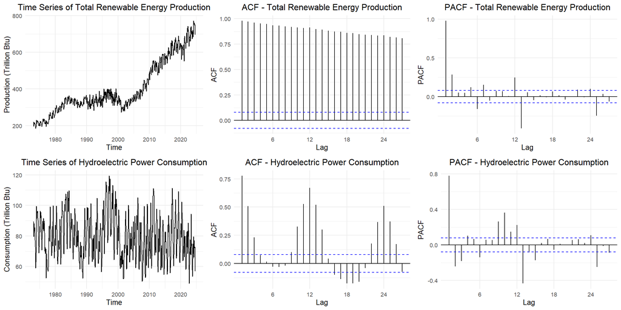

```r
renew_plot <- autoplot(ts_energy_data[, "Total Renewable Energy Production"]) +
  ggtitle("Time Series of Total Renewable Energy Production") +
  xlab("Time") + ylab("Production (Trillion Btu)")

#need to use ggAcf and ggPacf to return ggplot objects that are compatible with the plot_grid() function (otherwise it was throwing this error -  "Cannot convert object of class acf into a grob")

acf_renew <- ggAcf(ts_energy_data[, "Total Renewable Energy Production"]) + ggtitle("ACF - Total Renewable Energy Production")
pacf_renew <- ggPacf(ts_energy_data[, "Total Renewable Energy Production"]) + ggtitle("PACF - Total Renewable Energy Production")

hydro_energy_plot <- autoplot(ts_energy_data[, "Hydroelectric Power Consumption"]) +
  ggtitle("Time Series of Hydroelectric Power Consumption") +
  xlab("Time") + ylab("Consumption (Trillion Btu)")

acf_hydro <- ggAcf(ts_energy_data[, "Hydroelectric Power Consumption"]) + ggtitle("ACF - Hydroelectric Power Consumption")
pacf_hydro <- ggPacf(ts_energy_data[, "Hydroelectric Power Consumption"]) + ggtitle("PACF - Hydroelectric Power Consumption")

#combining all the plots into one grid using plot_grid() from the cowplot library
plot_grid(renew_plot, acf_renew, pacf_renew, hydro_energy_plot, acf_hydro, pacf_hydro, ncol=3)
```

### Q2

From the plot in Q1, do the series Total Renewable Energy Production and Hydroelectric Power Consumption appear to have a trend? If yes, what kind of trend?

#### Answer 2:

Trend: - Total Renewable Energy Production shows a non-linear increasing trend, with the period between 1985-2000 showing a stable trend on average. It has grown rapidly post 2002 (from around 300 Trillion Btu to more than 700 Trillion Btu). - Hydroelectric Power Consumption shows a relatively stable behaviour throughout the study period, with no significant upward or downward trend.

### Q3

Use the *lm()* function to fit a linear trend to the two time series. Ask R to print the summary of the regression. Interpret the regression output, i.e., slope and intercept. Save the regression coefficients for further analysis.

#### Answer 3:

```r
#creating a vector t
t <- c(1:n_obs)

renew_model <- lm(ts_energy_data[, "Total Renewable Energy Production"] ~ t)
summary(renew_model)
```

```
##
## Call:
## lm(formula = ts_energy_data[, "Total Renewable Energy Production"] ~
##     t)
##
## Residuals:
##     Min      1Q  Median      3Q     Max
## -151.11  -37.84   13.53   41.76  149.42
##
## Coefficients:
##              Estimate Std. Error t value Pr(>|t|)
## (Intercept) 176.87293    4.96189   35.65   <2e-16 ***
## t             0.72393    0.01382   52.37   <2e-16 ***
## ---
## Signif. codes:  0 '***' 0.001 '**' 0.01 '*' 0.05 '.' 0.1 ' ' 1
##
## Residual standard error: 61.75 on 619 degrees of freedom
## Multiple R-squared:  0.8159, Adjusted R-squared:  0.8156
## F-statistic:  2743 on 1 and 619 DF,  p-value: < 2.2e-16
```

```r
hydro_model <- lm(ts_energy_data[, "Hydroelectric Power Consumption"] ~ t)
summary(hydro_model)
```

```
##
## Call:
## lm(formula = ts_energy_data[, "Hydroelectric Power Consumption"] ~
##     t)
##
## Residuals:
##     Min      1Q  Median      3Q     Max
## -29.995 -10.422  -0.720   9.161  39.624
##
## Coefficients:
##             Estimate Std. Error t value Pr(>|t|)
## (Intercept) 82.96766    1.12339  73.855  < 2e-16 ***
## t           -0.01098    0.00313  -3.508 0.000485 ***
## ---
## Signif. codes:  0 '***' 0.001 '**' 0.01 '*' 0.05 '.' 0.1 ' ' 1
##
## Residual standard error: 13.98 on 619 degrees of freedom
## Multiple R-squared:  0.01949,    Adjusted R-squared:  0.01791
## F-statistic:  12.3 on 1 and 619 DF,  p-value: 0.0004848
```

```r
#extracting and saving the coefficients for future analysis
coeff_renew <- coef(renew_model)
coeff_hydro <- coef(hydro_model)
```

The intercepts on their own are essentially just a starting point, i.e., the estimated values of the variables at t = 0.

Significance: - The p-values for both the variables are less than 0.05. Thus, the linear relationship between time and the two variables is statistically meaningful.

Fitness: - The adjusted R-squared value for Total Renewable Energy Production is 0.8156, which means that 81.59% of the variation in renewable energy production is explained by the time variable. - On the other hand, only 1.95% of the variation in Hydroelectric Power COnsumption can be attributed to time.

Conclusion: - Total Renewable Energy Production shows a strong positive linear trend with time, and the linear model explains a signifcant portion of the variation. - Hydroelectric Power Consumption shows a slightly negative trend, but the linear model explans very little variation in the data, suggesting that other factors might be at play here.

### Q4

Use the regression coefficients from Q3 to detrend the series. Plot the detrended series and compare with the plots from Q1. What happened? Did anything change?

#### Answer 4:

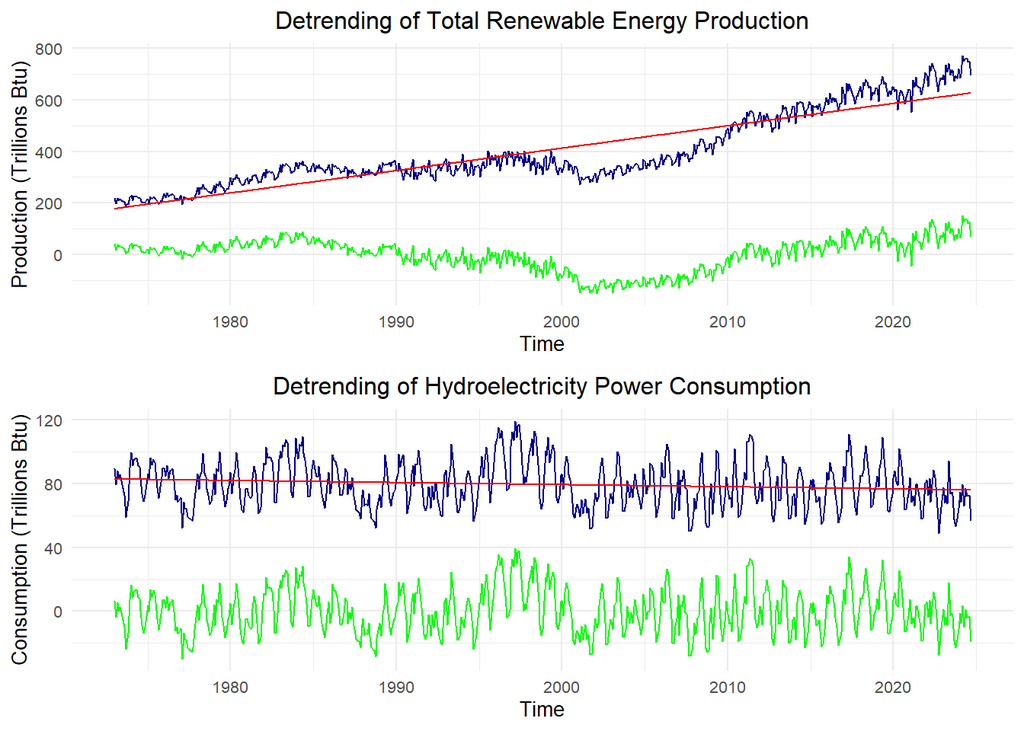

```r
#creating linear trends
linear_renew <- coeff_renew[1] + coeff_renew[2] * t
ts_linear_renew <- ts(linear_renew, start = c(1973, 1), frequency = 12)

linear_hydro <- coeff_hydro[1] + coeff_hydro[2] * t
ts_linear_hydro <- ts(linear_hydro, start = c(1973, 1), frequency = 12)

#detrending the series
detrend_renew <- energy_data_trim[, "Total Renewable Energy Production"] - linear_renew
ts_detrend_renew <- ts(detrend_renew, start = c(1973, 1), frequency = 12)

detrend_hydro <- energy_data_trim[, "Hydroelectric Power Consumption"] - linear_hydro
ts_detrend_hydro <- ts(detrend_hydro, start = c(1973, 1), frequency = 12)

#plotting the linear trend and the detrended series
detrend_renew_plot <- autoplot(ts_energy_data[, "Total Renewable Energy Production"], color = "darkblue")+
  autolayer(ts_detrend_renew, series = "Detrended", color = "green")+
  autolayer(ts_linear_renew, series = "Linear Component", color = "red") +
  labs(title = "Detrending of Total Renewable Energy Production",
       x = "Time", y = "Production (Trillions Btu)")

detrend_hydro_plot <- autoplot(ts_energy_data[, "Hydroelectric Power Consumption"], color = "darkblue")+
  autolayer(ts_detrend_hydro, series = "Detrended", color = "green")+
  autolayer(ts_linear_hydro, series = "Linear Component", color = "red") +
  labs(title = "Detrending of Hydroelectricity Power Consumption",
       x = "Time", y = "Consumption (Trillions Btu)")

plot_grid(detrend_renew_plot, detrend_hydro_plot, nrow = 2)
```

Note: Blue line is our original series; Red line is our trend; Green line is our detrended series (original series minus the trend)

The detrended series fluctuates around zero, which means that the long-term trend has been successfully removed, especially the increasing trend in the case of Total Renewable Energy Production. For the Hydroelectric Power Consumption, we do not see any significant change in the shape of the series (except that it shifted down to the zero line) because its linear trend was relatively flat.

### Q5

Plot ACF and PACF for the detrended series and compare with the plots from Q1. You may use plot_grid() again to get them side by side, but not mandatory. Did the plots change? How?

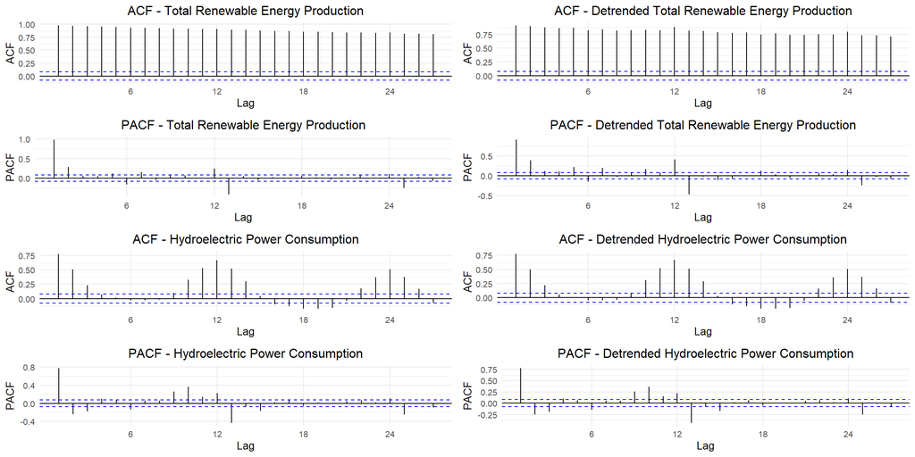

```r
acf_detrend_renew <- ggAcf(ts_detrend_renew) + ggtitle("ACF - Detrended Total Renewable Energy Production")
pacf_detrend_renew <- ggPacf(ts_detrend_renew) + ggtitle("PACF - Detrended Total Renewable Energy Production")

acf_detrend_hydro <- ggAcf(ts_detrend_hydro) + ggtitle("ACF - Detrended Hydroelectric Power Consumption")
pacf_detrend_hydro <- ggPacf(ts_detrend_hydro) + ggtitle("PACF - Detrended Hydroelectric Power Consumption")

plot_grid(acf_renew, acf_detrend_renew, pacf_renew, pacf_detrend_renew,
          acf_hydro, acf_detrend_hydro, pacf_hydro, pacf_detrend_hydro, ncol = 2)
```

ACF: - The absolute values of ACF for Renewable Energy Production decreased, indicating that the trend removal was successful. For instance, ACF at lag 2 decreased from ~1 to ~0.875. - For Hydroelectric Power Consumption, we don’t see any change in the ACF plot, confirming our hypothesis that there is no significant trend in this series.

PACF: - The PACF for Renewable Energy Production shows slightly higher values at later lags after detrending which could indicate the existence of seasonal components. - Similar to ACF, for Hydroelectric Power Consumption, we don’t see any change in the PACF plot.

## Seasonal Component

Set aside the detrended series and consider the original series again from Q1 to answer Q6 to Q8.

### Q6

Just by looking at the time series and the acf plots, do the series seem to have a seasonal trend? No need to run any code to answer your question. Just type in you answer below.

#### Answer 6:

Yes, both the time series seem to have a strong seasonality component to them as can be seen from the repeating patterns over time, aka yearly fluctuations, in the original time series plot. Additionally, the autocorrelation plot for Hydroelectric Power Consumption shows a wave-like pattern, with periodic spikes at a lag of 12. This indicates that there is a seasonal component to the dataset.

### Q7

Use function *lm()* to fit a seasonal means model (i.e. using the seasonal dummies) the two time series. Ask R to print the summary of the regression. Interpret the regression output. From the results which series have a seasonal trend? Do the results match you answer to Q6?

#### Answer 7:

```r
#using the seasonal means model on the original series
renew_dummies <- seasonaldummy(ts_energy_data[, "Total Renewable Energy Production"])
hydro_dummies <- seasonaldummy(ts_energy_data[, "Hydroelectric Power Consumption"])

renew_seas_model <- lm(ts_energy_data[, "Total Renewable Energy Production"] ~ renew_dummies)
summary(renew_seas_model)
```

```
##
## Call:
## lm(formula = ts_energy_data[, "Total Renewable Energy Production"] ~
##     renew_dummies)
##
## Residuals:
##     Min      1Q  Median      3Q     Max
## -205.65  -91.59  -54.59  117.87  356.19
##
## Coefficients:
##                  Estimate Std. Error t value Pr(>|t|)
## (Intercept)       410.598     20.228  20.299   <2e-16 ***
## renew_dummiesJan    1.973     28.468   0.069    0.945
## renew_dummiesFeb  -34.348     28.468  -1.207    0.228
## renew_dummiesMar    4.721     28.468   0.166    0.868
## renew_dummiesApr   -7.896     28.468  -0.277    0.782
## renew_dummiesMay    7.199     28.468   0.253    0.800
## renew_dummiesJun   -3.394     28.468  -0.119    0.905
## renew_dummiesJul    2.850     28.468   0.100    0.920
## renew_dummiesAug   -4.430     28.468  -0.156    0.876
## renew_dummiesSep  -29.037     28.468  -1.020    0.308
## renew_dummiesOct  -20.205     28.606  -0.706    0.480
## renew_dummiesNov  -20.706     28.606  -0.724    0.469
## ---
## Signif. codes:  0 '***' 0.001 '**' 0.01 '*' 0.05 '.' 0.1 ' ' 1
##
## Residual standard error: 144.5 on 609 degrees of freedom
## Multiple R-squared:  0.008696,   Adjusted R-squared:  -0.009209
## F-statistic: 0.4857 on 11 and 609 DF,  p-value: 0.9126
```

```r
hydro_seas_model <- lm(ts_energy_data[, "Hydroelectric Power Consumption"] ~ hydro_dummies)
summary(hydro_seas_model)
```

```
##
## Call:
## lm(formula = ts_energy_data[, "Hydroelectric Power Consumption"] ~
##     hydro_dummies)
##
## Residuals:
##     Min      1Q  Median      3Q     Max
## -31.101  -6.241  -0.444   6.410  32.363
##
## Coefficients:
##                  Estimate Std. Error t value Pr(>|t|)
## (Intercept)        79.981      1.452  55.094  < 2e-16 ***
## hydro_dummiesJan    4.941      2.043   2.418 0.015880 *
## hydro_dummiesFeb   -2.513      2.043  -1.230 0.219219
## hydro_dummiesMar    7.053      2.043   3.452 0.000595 ***
## hydro_dummiesApr    5.399      2.043   2.642 0.008441 **
## hydro_dummiesMay   13.907      2.043   6.807 2.40e-11 ***
## hydro_dummiesJun   10.729      2.043   5.251 2.09e-07 ***
## hydro_dummiesJul    4.033      2.043   1.974 0.048845 *
## hydro_dummiesAug   -5.399      2.043  -2.643 0.008436 **
## hydro_dummiesSep  -16.596      2.043  -8.123 2.54e-15 ***
## hydro_dummiesOct  -16.370      2.053  -7.973 7.66e-15 ***
## hydro_dummiesNov  -10.805      2.053  -5.263 1.97e-07 ***
## ---
## Signif. codes:  0 '***' 0.001 '**' 0.01 '*' 0.05 '.' 0.1 ' ' 1
##
## Residual standard error: 10.37 on 609 degrees of freedom
## Multiple R-squared:  0.4695, Adjusted R-squared:  0.4599
## F-statistic:    49 on 11 and 609 DF,  p-value: < 2.2e-16
```

```r
#extracting and saving the coefficients for future analysis
coeff_renew_seas <- coef(renew_seas_model)
coeff_hydro_seas <- coef(hydro_seas_model)
```

For Renewable Energy Production, none of the coefficients are statistically significant except for the intercept, which represents the average production for December (reference month). This means that monthly variations in renewable energy production are not statistically significant. Furthermore, the low R-squared value (-0.0092) indicates that seasonality explains very little variation in the renewable energy production.

On the other hand, several months for hydroelectric power consumption are statistically significant, indicating strong seasonal variation. ~46% of the variability in hydroelectric power consumption can be explained by the seasonal patterns. Thus, the regression results confirm that hydroelectric power consumption is strongly seasonal, but total renewable energy production is not.

### Q8

Use the regression coefficients from Q7 to deseason the series. Plot the deseason series and compare with the plots from part Q1. Did anything change?

#### Answer 8:

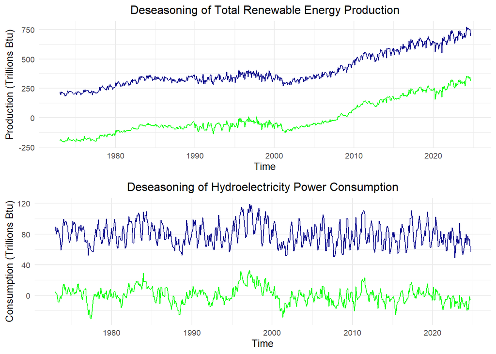

```r
renew_seas_comp <- array(0,n_obs)
for(i in 1:n_obs){
  renew_seas_comp[i] <- coeff_renew_seas[1] + coeff_renew_seas[2:12] %*% renew_dummies[i,]}

deseas_renew <- ts_energy_data[, "Total Renewable Energy Production"] - renew_seas_comp
ts_deseas_renew <- ts(deseas_renew, start = c(1973, 1), frequency = 12)

hydro_seas_comp <- array(0,n_obs)
for(i in 1:n_obs){
  hydro_seas_comp[i] <- coeff_hydro_seas[1] + coeff_hydro_seas[2:12] %*% hydro_dummies[i,]}

deseas_hydro <- ts_energy_data[, "Hydroelectric Power Consumption"] - hydro_seas_comp
ts_deseas_hydro <- ts(deseas_hydro, start = c(1973, 1), frequency = 12)

#plotting the deseasoned series
deseas_renew_plot <- autoplot(ts_energy_data[, "Total Renewable Energy Production"], color = "darkblue")+
  autolayer(ts_deseas_renew, color ="green") +
  labs(title = "Deseasoning of Total Renewable Energy Production",
       x = "Time", y = "Production (Trillions Btu)")
deseas_hydro_plot <- autoplot(ts_energy_data[, "Hydroelectric Power Consumption"], color = "darkblue")+
  autolayer(ts_deseas_hydro, color ="green") +
  labs(title = "Deseasoning of Hydroelectricity Power Consumption",
       x = "Time", y = "Consumption (Trillions Btu)")

plot_grid(deseas_renew_plot, deseas_hydro_plot, nrow = 2)
```

Note: Blue line is our original series; Green line is our deseasoned series (original series minus the seasonal component)

The deseasoned Renewable Energy Production series appears quite similar to the original series, confirming that the seaosnality component in this series is minimal (as we saw from the insignificant dummy variables). The deseasoned Hydroelectric Power Consumption, however, is much smoother, with seasonal fluctuations significantly reduced in the green line.

### Q9

Plot ACF and PACF for the deseason series and compare with the plots from Q1. You may use plot_grid() again to get them side by side, but not mandatory. Did the plots change? How?

#### Answer 9:

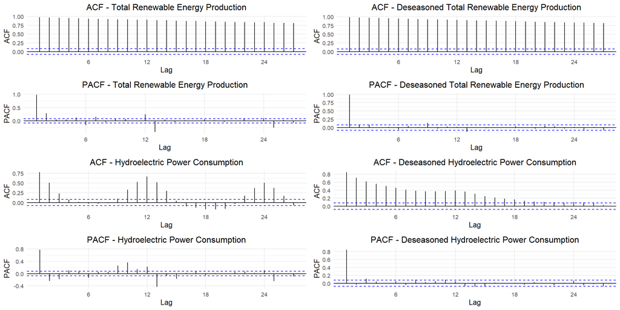

```r
acf_deseas_renew <- ggAcf(ts_deseas_renew) + ggtitle("ACF - Deseasoned Total Renewable Energy Production")
pacf_deseas_renew <- ggPacf(ts_deseas_renew) + ggtitle("PACF - Deseasoned Total Renewable Energy Production")

acf_deseas_hydro <- ggAcf(ts_deseas_hydro) + ggtitle("ACF - Deseasoned Hydroelectric Power Consumption")
pacf_deseas_hydro <- ggPacf(ts_deseas_hydro) + ggtitle("PACF - Deseasoned Hydroelectric Power Consumption")

plot_grid(acf_renew, acf_deseas_renew, pacf_renew, pacf_deseas_renew,
          acf_hydro, acf_deseas_hydro, pacf_hydro, pacf_deseas_hydro, ncol = 2)
```

(we see a switch in analysis compared with what we concluded between the original and detrended series.)

ACF: - For Renewable Energy Production, we don’t see any change in the ACF plot, confirming our hypothesis that there is no significant seasonality in this series. - Before deseasoning, ACF for Hydroelectric Power Consumption exhibits clear seasonality (with the wave-like pattern). Post removing the seasonal component, the ACF decays more gradually.

PACF: - PACF for Renewable Energy Production shows a similar trend as before, but the absolute values have decreased. - For Hydroelectric Power Consumption, PACF shows much weaker autocorrelations after lag 1. Most of them lie within the confidence bands, suggesting they are not statistically significant.